# Graded Project MAS6003

Registration number 160223367

April 3 25, 2017

It may be assumed that seeds from which the trees in the data-set grew were selected randomly from a seed bank and that the trees grew independently of each other.

# Task 1 - Identify model

“Use the data to identify a suitable growth model for Olly Bolly Dob Dob plants aged between 3 and 25 weeks.”

We examine the data by making a line plot of height versus age for all OllyBolly trees. By inspecting the plot we can see that the growth slows down with age.

```r
g1 <- ggplot(OllyBolly, aes(x = age , y=height)) + geom_line(aes(colour=Seed)) +
  theme(legend.position="none") + labs(title="A")
```

An examination of the data also revealed that a square root transformation of the heights is required to improve homoscedasticity of the model residues. In addition I did examine if plotting the square root of height versus the logarithm of the age makes the slope constant which would simplify the model be eliminating higher order terms.

```r
g2 <- ggplot(OllyBolly, aes(x = age , y=height)) + geom_line(aes(colour=Seed))+
  scale_x_log10()+ theme(legend.position="none") + scale_y_sqrt() + labs(title="B")
```

To represent $\log(age)$, $\sqrt{age}$ and $\sqrt{height}$ I introduced a new column `logAge`, `sqrtAge` and `sqrtHeight` in the OllyBolly dataframe.

```r
OllyBolly$logAge <- log(OllyBolly$age)
OllyBolly$sqrtAge <- sqrt(OllyBolly$age)
OllyBolly$sqrtHeight <- sqrt(OllyBolly$height)
```

After those transformations, for all ages starting with $5$, we have approximately an affine growth model.

. The growth curve from 3 to 5 weeks seems to come from a different process. Very likely the measurement at 3 weeks is unreliable since very close to the ground. Therefore, and because we anyhow do not plan to make predictions for the early growth phase, I decided to remove the age of 3 from the dataset.

```r
OllyBolly <- subset(OllyBolly, age > 4)
```

Figure 1 shows the original and the transformed growth curves.

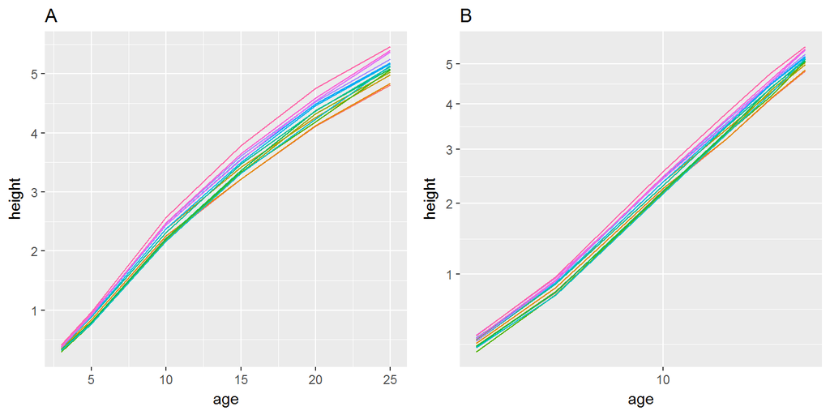

Tree height versus age (A), square root of height versus log10(age).

```r
multiplot(g1,g2,cols=2)
```

## Choosing the Fixed effects model.

Since a preliminary examination of model residues for the simple affine model, discussed above, revealed that a higher order term for age needs to be included, I compared the affine model with the higher order model and tested if I can reject that they equally explain the data using ANOVA.

- $\sqrt{Height}$ depends on $\log(Age)$ only.
- $\sqrt{Height}$ depends on $\log(Age)$ and $\sqrt{age}$.

```r
lme2 <- lmer(sqrtHeight ~ 1 + logAge + (1|Seed) ,
             data=OllyBolly, REML = F)
lme3 <- lmer(sqrtHeight ~ 1 + logAge + sqrtAge +  (1|Seed) ,
             data=OllyBolly, REML = F)
aovres <- anova(lme2, lme3)
obs.test.stat<- - 2*(logLik(lme2)-logLik(lme3))
1 - pchisq(obs.test.stat,1)
```

```
## 'log Lik.' 1.96995e-05 (df=4)
```

## Examining random effects

I also examined if a more complex structure for the random effects should be used.

- Compare models with various nested uncorrelated random effects.

```r
lme2R <- lmer(sqrtHeight ~ 1 + logAge + sqrtAge + (1|Seed)  ,
             data=OllyBolly, REML = F)
lme3R <- lmer(sqrtHeight ~ 1 + logAge + sqrtAge + (1|Seed) + (logAge - 1|Seed)  ,
             data=OllyBolly, REML = F)
lme4R <- lmer(sqrtHeight ~ 1 + logAge + sqrtAge + (1|Seed) + (logAge - 1|Seed) +
                (sqrtAge - 1|Seed) , data=OllyBolly, REML = F)
anovas <- anova(lme2R, lme3R, lme4R)
```

The ANOVA indicated that including $\sqrt{age}$ into the random effects does not significantly improve the model fit (results not shown). Finally, I also did examine if the correlation of the random effects should be modeled.

```r
lme5R <- lmer(sqrtHeight ~ 1 + logAge + sqrtAge +  (1 + logAge|Seed) ,
             data=OllyBolly, REML = F)
anovasres <- anova(lme3R, lme5R)
obs.test.stat<- - 2*(logLik(lme3R)-logLik(lme5R))
1 - pchisq(obs.test.stat,1)
```

```
## 'log Lik.' 0.007381803 (df=6)
```

Because of the small p-value, I reject the hypothesis that model `lme5r` and `lme3r` are equal and accept that `lme5r` better explains the data.

## Checking model assumptions

The model I selected is:

$$Y_{i,j} = \beta_0 + a_{i} + (\beta_1 + b_{i}) x_j + (\beta_2) x'_j + \epsilon_{ij}$$

where $Y_{ij}$ is the height of the plant $i$ after time $j$. $\beta_0$ is the population intercept, $\beta_1$ and $\beta_2$ describe the growth curve,

$$\begin{pmatrix}
a_i\\ b_i
\end{pmatrix} \sim N(0, \Sigma)$$

are the random effects with $\Sigma$ the covariance matrix, and $\epsilon \sim N(0,\sigma^2)$ are the model residues. For the `summary` of the model see Appendix. For all further analysis I will be using a a model fit obtained using REML.

```r
lmeChosen <- update(lme5R,  REML = T)
```

To check model assumptions I am using the following plots:

- I extract variances of random effects an make q-q plots for the variables Intercept and `logAge` (Panel - A and B) - looking for a straight line in both.
- Subject level residuals vs fitted values - looking for random scatter (Panel - C)
- q-q plot of subject-wise residuals to check the assumption that the errors $\epsilon$ are normally distributed (Panel - D).
- Population level residuals (Level 0) vs fitted values - looking for random scatter (Panel - E)
- Assess general fit of the model by plotting the measured tree heights vs fitted heights (Panel -F).

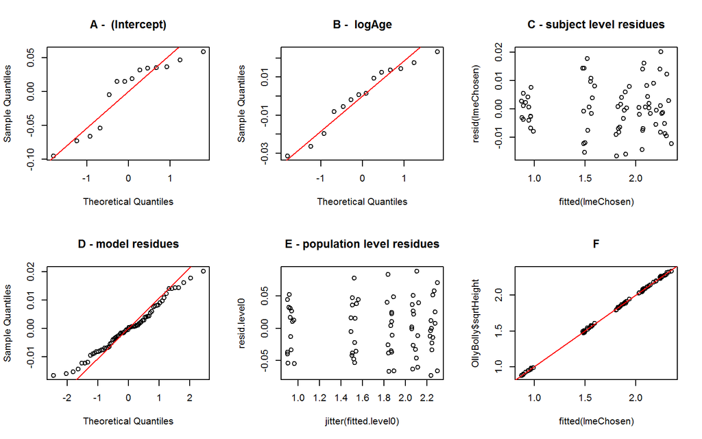

Diagnostic model plots. A - q-q plot of random effects for Intercept variable, B- q-q plot of random effects for logAge variable, C - subject level residues vs fitted values, D - q-q plot of subject wise residues, E - population level residuals, F - general fit of model

```r
raneffVar <- VarCorr(lmeChosen)
stdevs <-attributes(((raneffVar))$Seed)$stddev
par(mfrow=c(2,3))
randomEffects <- ranef(lmeChosen)[[1]]
qqnorm(randomEffects[,1],main=paste("A - ",names(randomEffects)[1])) #Panel - A
abline(c(0,stdevs[1]),col=2)
qqnorm(randomEffects[,2],main=paste("B - ", names(randomEffects)[2]))#Panel - B
abline(c(0,stdevs[2]),col=2)
plot(fitted(lmeChosen), resid(lmeChosen), main="C - subject level residues")# Panel - C
qqnorm(resid(lmeChosen), main="D - model residues") # Panel - D
abline(c(0,(summary(lmeChosen))$sigma),col=2)
fitted.level0<-lmeChosen@pp$X %*% fixef(lmeChosen) # Panel - E
resid.level0<-OllyBolly$sqrtHeight-fitted.level0
plot(jitter(fitted.level0),resid.level0, main="E - population level residues")
plot(fitted(lmeChosen),OllyBolly$sqrtHeight, main="F") # Panel - F
abline(0,1,col=2)
```

# Task 2 - Estimate height at 25 weeks

“Estimate the height at age $25$ weeks of another plant grown under similar conditions to those here, but from a different seed chosen randomly from the same seed bank.”

Using the function `simulate` we can simulate responses corresponding to the fitted model object.

```r
new.height<-simulate(lmeChosen, nsim=10000)^2
new.height.25 <- new.height[OllyBolly$age==25,]
```

The expected height of the plant will be 5.1372214. Furthermore, we can also say that in $95\%$ of cases, the height of the plant will be in the range 4.7412457, 5.5480586.

Alternatively, we can use the fixed effect coefficients to predict the expected height of a tree at the age of 25.

```r
fixef(lmeChosen)
```

```
## (Intercept)      logAge     sqrtAge
## -0.44103334  0.95649597 -0.07432639
```

```r
(pred25 <- fixef(lmeChosen)[1] + fixef(lmeChosen)[2] *log(25) + fixef(lmeChosen)[3] * sqrt(25))^2
```

```
## (Intercept)
##    5.135556
```

# Task 3 - Estimeate height at 25 given additional information about seed at age of 10 weeks.

“Furthermore, suppose that in addition, you are later told that this plant is $2.6m$ tall at $10$ weeks of age. Provide an updated estimate of the height of this plant at age $25$ weeks.”

To answer the question I am going to use simulation results from Task 2.

However, this time I selected only those simulated seeds where the height at the age of 10 is very close to $2.6$ (larger than $2.59$ and less $2.615$).

```r
new.height.10 <- new.height[OllyBolly$age==10,]
height.10_2.6 <- which(new.height.10 > (2.59) & new.height.10 < (2.615),arr.ind = T)
```

There are 1081 such seeds and their mean is 2.6018529. Only for those seeds, I examine the height at 25.

```r
new.height.25 <- new.height[OllyBolly$age==25,]
height.25_height2.6At10 <- new.height.25[height.10_2.6]
```

The average height of the tree in meters after 25 weeks, for those trees that were $2.6$ meter high at the age of $10$ weeks, is:

```r
mean(height.25_height2.6At10)
```

```
## [1] 5.525216
```

In addition, we easily can estimate the $95\%$ confidence interval which is:

```r
quantile(height.25_height2.6At10, c(0.025,0.975))
```

```
##     2.5%    97.5%
## 5.300931 5.738926
```

Figure 3 illustrates the distribution of the simulated heights at age of 25 for all trees (Panel A) and those with height 2.6 at the age of 10 weeks (Panel B).

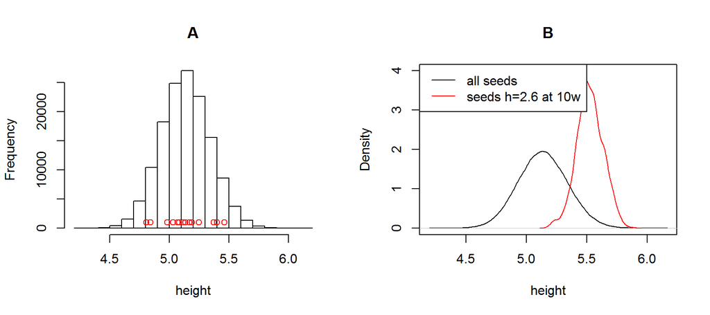

Panel A : Histogram of simulated heights at age 25. The red dots indicate the measured tree heights at age 25. Panel B: Density plot of heights at age 25 (black) while in red is the density plot at age 25 weeks for those seeds which had a height of 2.6 at the age of 10.

```r
par(mfrow=c(1,2))

# Panel A
hist(unlist(new.height.25), main="A", xlab="height")
Olb25<-subset(OllyBolly, age==25)
points(Olb25$height, rep(1000, nrow(Olb25)), col=2, type="p")

# Panel B

plot(density(unlist(new.height.25)), ylim=c(0,4), main="B",xlab="height")
lines(density(height.25_height2.6At10),col=2)
legend("topleft", legend = c("all seeds", "seeds h=2.6 at 10w"), lty = 1, col=c(1,2))
```